# Challenge

The idea behind this challenge is for you to explore the dataset, build a prediction model from it and then code a Python module that serves the model. Therefore there will be two main parts:

1. Your Jupyter (IPython) notebook containing all your experiments, analyzes, and results. In this notebook, you will perform all your visualizations, data normalizations, training and evaluation of your model.
2. A complete Python module ready to be used containing the model you trained. This module should be coded as if the engineering team would use it so it must contain usage instructions and a clear interface (generally speaking) to access your model.

## The dataset

Kickstarter is one of the main online crowdfunding platforms in the world. The dataset provided contains more de 300,000 projects launched on the platform in 2018. In the `data.csv` file there are the following columns:

- **ID**: internal ID, *numeric*
- **name**: name of the project, *string*
- **category**: project's category, *string*
- **main_category**: campaign's category, *string*
- **currency**: project's currency, *string*
- **deadline**: project's deadline date, *timestamp*
- **goal**: fundraising goal, *numeric*
- **launched**: project's start date, *timestamp*
- **pledged**: amount pledged by backers (project's currency), *numeric*
- **state**: project's current state, *string*; **this is what you have to predict**
- **backers**: amount of people that backed the project, *numeric*
- **country**: project's country, *string*
- **usd pledged**: amount pledged by backers converted to USD (conversion made by KS), *numeric*
- **usd_pledged_real**: amount pledged by backers converted to USD (conversion made by fixer.io api), *numeric*
- **usd_goal_real**: fundraising goal is USD, *numeric*

## Goal

Your goal is to predict whether a project will be successful or not. It is entirely up to you which features you will use and which model. When it comes to performance metrics you should be able to say when the model is good enough. There are no minimum requirements or tricky conditions. What we are trying to evaluate is how you handle an unknown dataset in a classification task and your ability to deliver the results.

## Deliverables

Do not use this notebook for your submission. The expected outputs are:

1. A Jupyter (IPython) notebook (that you have to create) containing your work and explanations. This is where you will put all your experiments, notes, visualizations and transformations in the data. This is also where you will prepare your data and train your prediction model.
2. A Python module containing your model and functions to use to predict Kickstarter projects' state. Assume that in order to review your work an engineer will import this module and try to make some predictions so your model should be in it.
3. A Markdown file containing usage instructions for your Python module.

```python
import sys
try:
    sys.getwindowsversion()
except AttributeError:
    isWindows = False
else:
    isWindows = True
if isWindows:
    import win32api,win32process,win32con
    pid = win32api.GetCurrentProcessId()
    handle = win32api.OpenProcess(win32con.PROCESS_ALL_ACCESS, True, pid)
    win32process.SetPriorityClass(handle, win32process.HIGH_PRIORITY_CLASS)
import warnings
warnings.filterwarnings('ignore')

import pandas as pd
import numpy as np
import seaborn as sns
import matplotlib.pyplot as plt
from sklearn import cross_validation
from sklearn.cross_validation import train_test_split
from sklearn.ensemble import RandomForestClassifier
from sklearn.grid_search import GridSearchCV, RandomizedSearchCV
from sklearn.linear_model import LogisticRegression
from sklearn.metrics import accuracy_score, classification_report, confusion_matrix, roc_auc_score, roc_curve
from sklearn.tree import DecisionTreeClassifier
from sklearn.preprocessing import MinMaxScaler
from sklearn import metrics
from datetime import datetime
import time
import nltk
nltk.download('stopwords')
from nltk.corpus import stopwords
stop = stopwords.words('english')
from sklearn.model_selection import KFold
from sklearn.model_selection import StratifiedKFold
import itertools

%matplotlib inline
```

```python
df=pd.read_csv("data.csv", engine = 'c')
```

## Basic EDA

```python
print("Table 1: Summary of Values")
df.describe()
```

```
Table 1: Summary of Values
```

|  | ID | goal | pledged | backers | usd pledged | usd_pledged_real | usd_goal_real |
| --- | --- | --- | --- | --- | --- | --- | --- |
| count | 3.786610e+05 | 3.786610e+05 | 3.786610e+05 | 378661.000000 | 3.748640e+05 | 3.786610e+05 | 3.786610e+05 |
| mean | 1.074731e+09 | 4.908079e+04 | 9.682979e+03 | 105.617476 | 7.036729e+03 | 9.058924e+03 | 4.545440e+04 |
| std | 6.190862e+08 | 1.183391e+06 | 9.563601e+04 | 907.185035 | 7.863975e+04 | 9.097334e+04 | 1.152950e+06 |
| min | 5.971000e+03 | 1.000000e-02 | 0.000000e+00 | 0.000000 | 0.000000e+00 | 0.000000e+00 | 1.000000e-02 |
| 25% | 5.382635e+08 | 2.000000e+03 | 3.000000e+01 | 2.000000 | 1.698000e+01 | 3.100000e+01 | 2.000000e+03 |
| 50% | 1.075276e+09 | 5.200000e+03 | 6.200000e+02 | 12.000000 | 3.947200e+02 | 6.243300e+02 | 5.500000e+03 |
| 75% | 1.610149e+09 | 1.600000e+04 | 4.076000e+03 | 56.000000 | 3.034090e+03 | 4.050000e+03 | 1.550000e+04 |
| max | 2.147476e+09 | 1.000000e+08 | 2.033899e+07 | 219382.000000 | 2.033899e+07 | 2.033899e+07 | 1.663614e+08 |

```python
df = df.drop(columns=['goal','pledged'])
```

## Missing Values

```python
df.isnull().T.any().T.sum()
```

```
3801
```

```python
df.isna().any()
```

```
ID                  False
name                 True
category            False
main_category       False
currency            False
deadline            False
launched            False
state               False
backers             False
country             False
usd pledged          True
usd_pledged_real    False
usd_goal_real       False
dtype: bool
```

```python
print("Table 3: Summary of Categorical Values")
df[df.columns[df.dtypes == "O"]].describe()
```

```
Table 3: Summary of Categorical Values
```

|  | name | category | main_category | currency | deadline | launched | state | country |
| --- | --- | --- | --- | --- | --- | --- | --- | --- |
| count | 378657 | 378661 | 378661 | 378661 | 378661 | 378661 | 378661 | 378661 |
| unique | 375764 | 159 | 15 | 14 | 3164 | 378089 | 6 | 23 |
| top | New EP/Music Development | Product Design | Film & Video | USD | 2014-08-08 | 1970-01-01 01:00:00 | failed | US |
| freq | 41 | 22314 | 63585 | 295365 | 705 | 7 | 197719 | 292627 |

## Creation of Dummy Variables with Missing Values

```python
df['usd pledged missing'] = np.where(df['usd pledged'].isnull(), 1, 0)
df['usd pledged'] = df['usd pledged'].fillna(0)
df['date launched'], df['time of launch'] = df['launched'].str.split(' ', 1).str
df = df.drop(columns='launched')
```

## Date Conversion is the Threshold for Live Vs Fail

```python
def compare_dates(date):
    date_format = '%Y-%m-%d'
    current_date = datetime.strptime(date, date_format)
    start = datetime(2009,4,1)
    diff = current_date - start
    return diff.days

#apply this function to your pandas dataframe
df['Days_Launched_Since_4_2009'] = df['date launched'].apply(compare_dates)
df['Days_Deadline_Since_4_2009'] = df['deadline'].apply(compare_dates)

df = df.drop(columns=['date launched','deadline'])
```

```python
df['more days to go'] = np.where(df['Days_Deadline_Since_4_2009']>3170, 1, 0)
```

```python
df['Days_Launched_missing'] = np.where(df['Days_Launched_Since_4_2009']==-14362, 1, 0)
df['days hosted'] = df['Days_Deadline_Since_4_2009']-df['Days_Launched_Since_4_2009']

mask = df['Days_Launched_Since_4_2009']==-14335
column_name = 'days hosted','Days_Launched_Since_4_2009'
df.loc[mask, column_name] = 0
```

## Time Conversion

```python
def time_convert(x):
    h,m,s = map(int,x.split(':'))
    return (h*60+m)*60+s

df['time of launch']=df['time of launch'].apply(time_convert)
```

## Backers and USD raised for Success Vs Fail

```python
supporters = ['backers','usd_pledged_real']

for column in supporters:
    df['NO '+column] = np.where(df[column]==0, 1, 0)
```

## Goal Met Distinguishes Success Vs Fail

```python
sub_columns = ['usd_pledged_real']

for column in sub_columns:
    df['usd_goal-'+column] = df['usd_goal_real']-df[column]
```

```python
df['Goal Met'] = np.where(df['usd_goal-usd_pledged_real']<=0, 1, 0)
df = df.drop(columns='usd_goal-usd_pledged_real')
```

## Basic Text Processing of Title to Donation Perception

```python
df['Uppercase'] = df['name'].str.findall(r'[A-Z]').str.len()
df['Lowercase'] = df['name'].str.findall(r'[a-z]').str.len()
df['numbers'] = df['name'].str.findall(r'[0-9]').str.len()
df['Non Alphanumeric'] = df['name'].str.findall(r'[^a-zA-Z0-9 ]').str.len()

df['Uppercase'] = df['Uppercase'].fillna(0)
df['Lowercase'] = df['Lowercase'].fillna(0)
df['numbers'] = df['numbers'].fillna(0)
df['Non Alphanumeric'] = df['Non Alphanumeric'].fillna(0)

df['total']=df['Uppercase']+df['Lowercase']+df['numbers']+df['Non Alphanumeric']

df['Uppercase']=df['Uppercase']/df['total']
df['Lowercase']=df['Lowercase']/df['total']
df['numbers']=df['numbers']/df['total']
df['Non Alphanumeric']=df['Non Alphanumeric']/df['total']

df['Uppercase'] = df['Uppercase'].fillna(0)
df['Lowercase'] = df['Lowercase'].fillna(0)
df['numbers'] = df['numbers'].fillna(0)
df['Non Alphanumeric'] = df['Non Alphanumeric'].fillna(0)

df = df.drop(columns='total')
```

## Stop Words and Non Alphanumerics

```python
#remove returns and newlines, nonalphanumeric
df['name'] = df['name'].str.replace('[^a-zA-Z ]', ' ')
df['name'] = df['name'].replace('\n',' ', regex=True).replace('\r',' ', regex=True)
```

```python
df['name'].fillna("nullvalue", inplace=True)
df['name'] = df['name'].replace('\s+', ' ', regex=True)
```

```python
#remove stopwords
start = time.time()
df['name_no_stopwords'] = df['name'].apply(lambda x: ' '.join([word for word in x.split() if word not in (stop)]))
df['name_no_stopwords'] = df['name_no_stopwords'].replace('\s+', ' ', regex=True)
time.strftime("%H:%M:%S", time.gmtime(time.time() - start))
```

```
'00:00:05'
```

## Character Count

```python
df['name_Words'] = df['name'].str.split().str.len()
df['name_Words_No_Stopwords'] = df['name_no_stopwords'].str.split().str.len()
```

## Name has Canceled and Suspended Indicators: data leak, but fair game

```python
df['name_no_stopwords'] = df['name_no_stopwords'].str.lower()

df['has canceled'] = df['name_no_stopwords'].str.contains('canceled').astype(int)+df['name_no_stopwords'].str.contains('cancelled').astype(int)
df['has suspended'] = df['name_no_stopwords'].str.contains('suspended').astype(int)

df = df.drop(columns=['name_no_stopwords','name'])
```

## Data Transformations

```python
log_columns = ['backers','usd_pledged_real','usd_goal_real','Days_Deadline_Since_4_2009','usd pledged',
               'name_Words','name_Words_No_Stopwords','Days_Launched_Since_4_2009']

for column in log_columns:
    df[column+'*'] = np.log(df[column]+1)

df = df.drop(columns=log_columns)
```

## Distribution Visualization

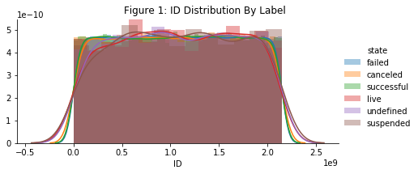

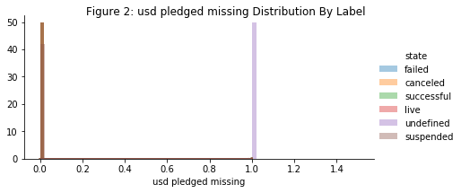

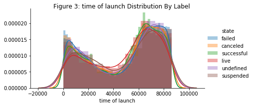

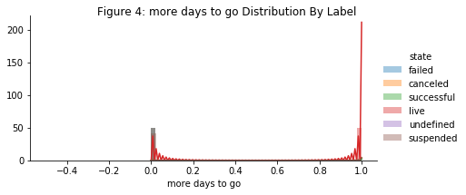

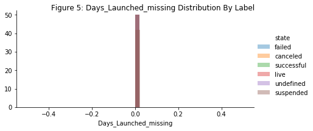

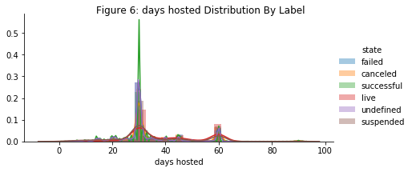

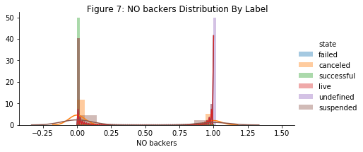

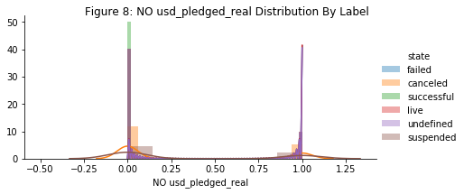

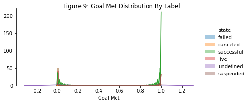

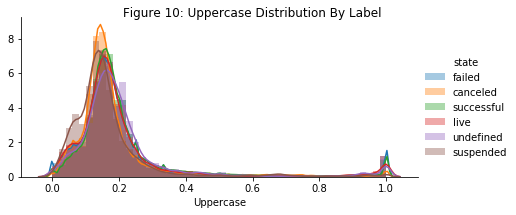

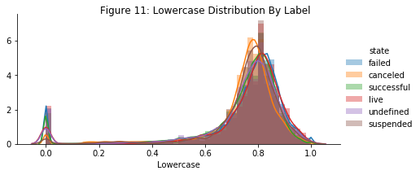

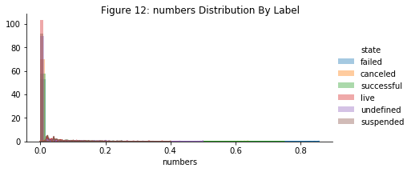

[11 more figures not shown]

```python
plt.rcParams['figure.max_open_warning']=40
colnames=list(df.select_dtypes(exclude='O').columns.values)
for i in colnames[0:]:
    facet = sns.FacetGrid(df,hue='state',aspect=2)
    facet.map(sns.distplot,i)
    facet.add_legend()
    facet.fig.suptitle(''.join(map(str, list(["Figure ",colnames.index(i)+1,": ",i," Distribution By Label"]))))
    plt.show()
```

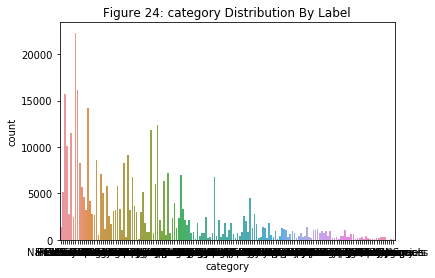

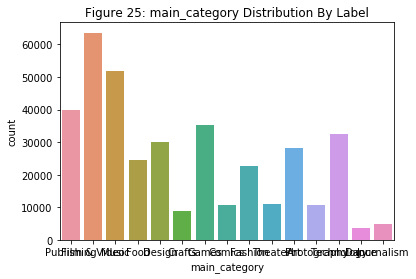

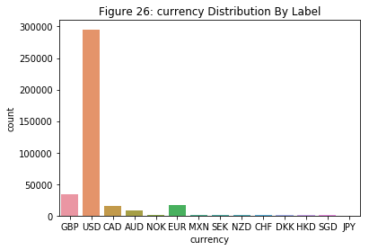

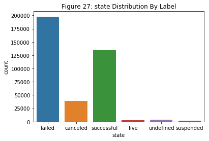

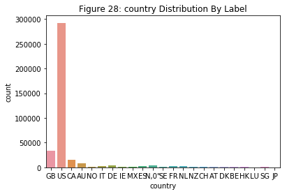

```python
plt.rcParams['figure.max_open_warning']=40
colnames=list(df.select_dtypes(include='O').columns.values)
for i in colnames[0:]:
    ax = plt.axes()
    sns.countplot(x=i, data=df, ax = ax)
    ax.set_title(''.join(map(str, list(["Figure ",colnames.index(i)+24,": ",i," Distribution By Label"]))))
    plt.show()
```

## Drop Category and keep Main Category

```python
df = df.drop(columns=['category'])
```

## Separation of Target Variable

```python
y = df.pop('state')

# ids = pd.Series(y.unique())
# ids = ids.reset_index().set_index(0)
# y_int = ids.loc[y]
```

## Categorical to Dummy Variables

```python
colnames=list(df.select_dtypes(include='O').columns.values)
for i in colnames[0:]:
    # Fill missing data with the word "Missing"
    df[i].fillna("Missing", inplace=True)
    # Create array of dummies
    dummies = pd.get_dummies(df[i], prefix=i)
    # Update X to include dummies and drop the main variable
    df = pd.concat([df, dummies], axis=1)
    df.drop([i], axis=1, inplace=True)
```

## Scale the Data for Later Feature Importance Evaluation and StratifiedKFold

```python
columns = df.columns
sc = MinMaxScaler(feature_range=(0, 1))
df = sc.fit_transform(df)
df = pd.DataFrame(df, columns=columns)

#x_train, x_test, y_train, y_test = train_test_split(df, y_int, test_size=0.33, random_state=2, stratify=y_int)
skf = StratifiedKFold(n_splits = 3, shuffle = True, random_state = 2)
```

## Decision Tree Vs Random Forest

```python
model2 = DecisionTreeClassifier()

for train_idx, test_idx in skf.split(df, y):
    model2.fit(df.loc[train_idx],y.loc[train_idx])
    print(classification_report(y.loc[test_idx],model2.predict(df.loc[test_idx])))
```

```
             precision    recall  f1-score   support

   canceled       0.65      0.69      0.67     12927
     failed       0.94      0.93      0.93     65907
       live       0.92      0.91      0.92       933
 successful       1.00      1.00      1.00     44652
  suspended       0.53      0.59      0.56       616
  undefined       1.00      1.00      1.00      1188

avg / total       0.93      0.93      0.93    126223

             precision    recall  f1-score   support

   canceled       0.65      0.68      0.67     12926
     failed       0.94      0.93      0.93     65906
       live       0.91      0.90      0.91       933
 successful       1.00      1.00      1.00     44652
  suspended       0.53      0.54      0.53       615
  undefined       1.00      1.00      1.00      1187

avg / total       0.93      0.93      0.93    126219

             precision    recall  f1-score   support

   canceled       0.65      0.69      0.67     12926
     failed       0.94      0.93      0.93     65906
       live       0.92      0.89      0.91       933
 successful       1.00      1.00      1.00     44652
  suspended       0.53      0.60      0.56       615
  undefined       1.00      1.00      1.00      1187

avg / total       0.93      0.93      0.93    126219
```

```python
model3 = RandomForestClassifier(random_state=2, n_jobs=-1)

for train_idx, test_idx in skf.split(df, y):
    model3.fit(df.loc[train_idx],y.loc[train_idx])
    print(classification_report(y.loc[test_idx],model3.predict(df.loc[test_idx])))
```

```
             precision    recall  f1-score   support

   canceled       0.91      0.62      0.74     12927
     failed       0.93      0.99      0.96     65907
       live       0.92      0.98      0.95       933
 successful       1.00      1.00      1.00     44652
  suspended       0.99      0.52      0.69       616
  undefined       1.00      1.00      1.00      1188

avg / total       0.95      0.95      0.95    126223

             precision    recall  f1-score   support

   canceled       0.90      0.62      0.74     12926
     failed       0.93      0.99      0.96     65906
       live       0.91      0.98      0.94       933
 successful       1.00      1.00      1.00     44652
  suspended       1.00      0.50      0.67       615
  undefined       1.00      1.00      1.00      1187

avg / total       0.95      0.95      0.95    126219

             precision    recall  f1-score   support

   canceled       0.91      0.63      0.74     12926
     failed       0.93      0.99      0.96     65906
       live       0.92      0.97      0.95       933
 successful       1.00      1.00      1.00     44652
  suspended       0.99      0.53      0.69       615
  undefined       0.99      1.00      1.00      1187

avg / total       0.95      0.95      0.95    126219
```

## Continue with Random Forest Multi Class Classification

```python
model4 = RandomForestClassifier(n_estimators=100, random_state=2, n_jobs=-1)

for train_idx, test_idx in skf.split(df, y):
    model4.fit(df.loc[train_idx],y.loc[train_idx])
    print(classification_report(y.loc[test_idx],model4.predict(df.loc[test_idx])))
```

```
             precision    recall  f1-score   support

   canceled       0.99      0.60      0.75     12927
     failed       0.93      1.00      0.96     65907
       live       0.92      0.99      0.95       933
 successful       1.00      1.00      1.00     44652
  suspended       1.00      0.56      0.72       616
  undefined       0.99      1.00      1.00      1188

avg / total       0.96      0.96      0.95    126223

             precision    recall  f1-score   support

   canceled       0.99      0.60      0.75     12926
     failed       0.93      1.00      0.96     65906
       live       0.92      0.99      0.95       933
 successful       1.00      1.00      1.00     44652
  suspended       1.00      0.53      0.69       615
  undefined       1.00      1.00      1.00      1187

avg / total       0.96      0.96      0.95    126219

             precision    recall  f1-score   support

   canceled       1.00      0.60      0.75     12926
     failed       0.93      1.00      0.96     65906
       live       0.92      0.98      0.95       933
 successful       1.00      1.00      1.00     44652
  suspended       0.99      0.58      0.74       615
  undefined       0.99      1.00      1.00      1187

avg / total       0.96      0.96      0.95    126219
```

## Feature Importance and Removal of Non Important Features

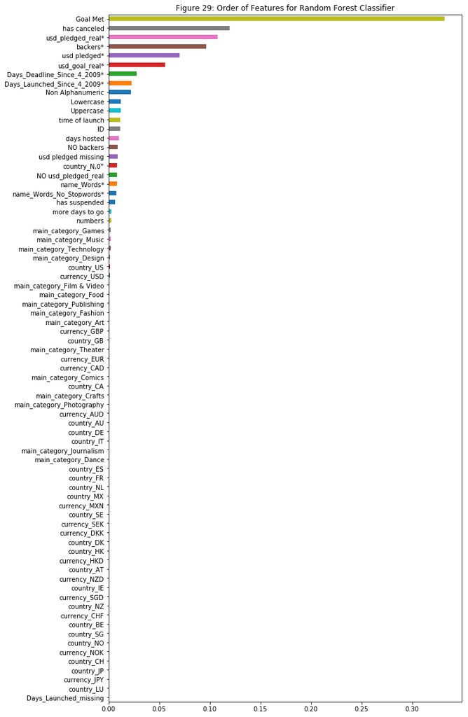

```python
feature_importances = pd.Series(model4.feature_importances_, index=df.columns)
feature_importances.sort_values().plot(kind="barh", figsize=(10,20),
                                       title = "Figure 29: Order of Features for Random Forest Classifier");
```

```python
print("Table 4: Lesser Features of Random Forest Classifier")
feature_importances.sort_values()[:52]
```

```
Table 4: Lesser Features of Random Forest Classifier
```

```
Days_Launched_missing         0.000000
country_LU                    0.000002
currency_JPY                  0.000012
country_JP                    0.000015
country_CH                    0.000092
currency_NOK                  0.000093
country_NO                    0.000094
country_SG                    0.000100
country_BE                    0.000102
currency_CHF                  0.000103
country_NZ                    0.000104
currency_SGD                  0.000105
country_IE                    0.000105
currency_NZD                  0.000105
country_AT                    0.000110
currency_HKD                  0.000126
country_HK                    0.000127
country_DK                    0.000132
currency_DKK                  0.000142
currency_SEK                  0.000148
country_SE                    0.000161
currency_MXN                  0.000193
country_MX                    0.000196
country_NL                    0.000222
country_FR                    0.000231
country_ES                    0.000243
main_category_Dance           0.000267
main_category_Journalism      0.000312
country_IT                    0.000325
country_DE                    0.000354
country_AU                    0.000380
currency_AUD                  0.000388
main_category_Photography     0.000403
main_category_Crafts          0.000452
country_CA                    0.000531
main_category_Comics          0.000541
currency_CAD                  0.000545
currency_EUR                  0.000621
main_category_Theater         0.000671
country_GB                    0.000699
currency_GBP                  0.000707
main_category_Art             0.000853
main_category_Fashion         0.000930
main_category_Publishing      0.000946
main_category_Food            0.000988
main_category_Film & Video    0.001036
currency_USD                  0.001239
country_US                    0.001264
main_category_Design          0.001626
main_category_Technology      0.001921
main_category_Music           0.002082
main_category_Games           0.002407
dtype: float64
```

```python
# x_test.drop(feature_importances.sort_values()[:214].index, axis=1, inplace=True)
# x_train.drop(feature_importances.sort_values()[:214].index, axis=1, inplace=True)
df.drop(feature_importances.sort_values()[:52].index, axis=1, inplace=True)
```

## Ensure Same Prediction Metrics, Iterative

```python
model = RandomForestClassifier(n_estimators=100, random_state=2, n_jobs=-1)

for train_idx, test_idx in skf.split(df, y):
    model.fit(df.loc[train_idx],y.loc[train_idx])
    print(classification_report(y.loc[test_idx],model.predict(df.loc[test_idx])))
```

```
             precision    recall  f1-score   support

   canceled       0.99      0.60      0.75     12927
     failed       0.93      1.00      0.96     65907
       live       0.92      0.99      0.95       933
 successful       1.00      1.00      1.00     44652
  suspended       1.00      0.57      0.73       616
  undefined       0.99      1.00      1.00      1188

avg / total       0.96      0.96      0.95    126223

             precision    recall  f1-score   support

   canceled       0.99      0.60      0.74     12926
     failed       0.93      1.00      0.96     65906
       live       0.91      0.99      0.95       933
 successful       1.00      1.00      1.00     44652
  suspended       1.00      0.53      0.70       615
  undefined       1.00      1.00      1.00      1187

avg / total       0.96      0.96      0.95    126219

             precision    recall  f1-score   support

   canceled       0.99      0.60      0.75     12926
     failed       0.93      1.00      0.96     65906
       live       0.92      0.98      0.95       933
 successful       1.00      1.00      1.00     44652
  suspended       0.98      0.59      0.74       615
  undefined       0.99      1.00      1.00      1187

avg / total       0.96      0.96      0.95    126219
```

## Feature Importance for Prediction

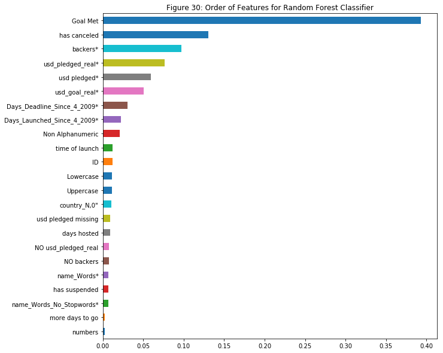

```python
feature_importances = pd.Series(model.feature_importances_, index=df.columns)
feature_importances.sort_values().plot(kind="barh", figsize=(10,10),
                                       title = "Figure 30: Order of Features for Random Forest Classifier");
```

## Optimization of Hyperparameters

```python
hyperparameters = {'min_samples_split': [2,3,4],
                   'max_features': ['auto', 'sqrt', 'log2'],
                   'criterion': ['entropy']
                  }
rfc = RandomForestClassifier(n_jobs=-1, random_state=2, n_estimators=100)

search = GridSearchCV(rfc, hyperparameters, cv=5, scoring='accuracy')

search.fit(df.loc[train_idx],y.loc[train_idx])

search.best_estimator_
```

```
RandomForestClassifier(bootstrap=True, class_weight=None, criterion='entropy',
            max_depth=None, max_features='auto', max_leaf_nodes=None,
            min_impurity_decrease=0.0, min_impurity_split=None,
            min_samples_leaf=1, min_samples_split=2,
            min_weight_fraction_leaf=0.0, n_estimators=100, n_jobs=-1,
            oob_score=False, random_state=2, verbose=0, warm_start=False)
```

## Increase Estimators

```python
rfc = RandomForestClassifier(criterion='entropy',
                               n_estimators=1000,
                               n_jobs=-1,
                               random_state=2,
                               max_features='auto',
                               min_samples_split=2)

for train_idx, test_idx in skf.split(df, y):
    rfc.fit(df.loc[train_idx],y.loc[train_idx])
    print(classification_report(y.loc[test_idx],rfc.predict(df.loc[test_idx])))
```

```
             precision    recall  f1-score   support

   canceled       1.00      0.60      0.75     12927
     failed       0.93      1.00      0.96     65907
       live       0.92      0.99      0.95       933
 successful       1.00      1.00      1.00     44652
  suspended       1.00      0.57      0.73       616
  undefined       0.99      1.00      1.00      1188

avg / total       0.96      0.96      0.95    126223

             precision    recall  f1-score   support

   canceled       0.99      0.60      0.75     12926
     failed       0.93      1.00      0.96     65906
       live       0.91      0.99      0.95       933
 successful       1.00      1.00      1.00     44652
  suspended       1.00      0.53      0.70       615
  undefined       1.00      1.00      1.00      1187

avg / total       0.96      0.96      0.95    126219

             precision    recall  f1-score   support

   canceled       1.00      0.60      0.75     12926
     failed       0.93      1.00      0.96     65906
       live       0.91      0.99      0.95       933
 successful       1.00      1.00      1.00     44652
  suspended       0.98      0.59      0.74       615
  undefined       0.99      1.00      1.00      1187

avg / total       0.96      0.96      0.95    126219
```

## Visual Confusion Matrix of Multi-Class Prediction

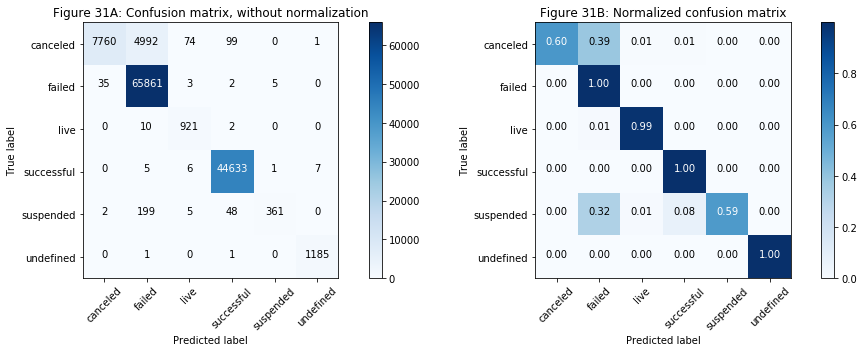

```python
def plot_confusion_matrix(cm, classes,
                          normalize=False,
                          title='Confusion matrix',
                          cmap=plt.cm.Blues):
    """
    This function prints and plots the confusion matrix.
    Normalization can be applied by setting `normalize=True`.
    """
    if normalize:
        cm = cm.astype('float') / cm.sum(axis=1)[:, np.newaxis]

    plt.imshow(cm, interpolation='nearest', cmap=cmap)
    plt.title(title)
    plt.colorbar()
    tick_marks = np.arange(len(classes))
    plt.xticks(tick_marks, classes, rotation=45)
    plt.yticks(tick_marks, classes)

    fmt = '.2f' if normalize else 'd'
    thresh = cm.max() / 2.
    for i, j in itertools.product(range(cm.shape[0]), range(cm.shape[1])):
        plt.text(j, i, format(cm[i, j], fmt),
                 horizontalalignment="center",
                 color="white" if cm[i, j] > thresh else "black")

    plt.tight_layout()
    plt.ylabel('True label')
    plt.xlabel('Predicted label')

# Compute confusion matrix
cnf_matrix = confusion_matrix(y.loc[test_idx],rfc.predict(df.loc[test_idx]))
np.set_printoptions(precision=2)

class_names = ['canceled', 'failed', 'live', 'successful', 'suspended', 'undefined']

# Plot non-normalized confusion matrix
plt.figure(figsize = (15,5))
plt.subplot(1, 2, 1)
plot_confusion_matrix(cnf_matrix, classes=class_names, title='Figure 31A: Confusion matrix, without normalization')

# Plot normalized confusion matrix
plt.subplot(1, 2, 2)
plot_confusion_matrix(cnf_matrix, classes=class_names, normalize=True, title='Figure 31B: Normalized confusion matrix')

plt.tight_layout()
plt.show()
```